# Cyclistic Project

Uthman

2022-12-12

## Cyclistic case study

### Introduction

This is a data analysis case study for the Google Data Analytics course. The essence of this project is to perform a real-world task of a junior data analyst.I am imagining that I am working for Cyclistic, a bike-share company in Chicago .The director of marketing believes the company’s future success depends on maximizing the number of annual memberships. Therefore,my team wants to understand how casual riders and annual members use Cyclistic bikes differently. From these insights,my team will design a new marketing strategy to convert casual riders into annual members. But first, Cyclistic executives must approve our recommendations, so they must be backed up with compelling data insights and professional data visualizations.

### About the company

In 2016, Cyclistic launched a successful bike-share offering. Since then, the program has grown to a fleet of 5,824 bicycles that are geotracked and locked into a network of 692 stations across Chicago. The bikes can be unlocked from one station and returned to any other station in the system anytime.Until now, Cyclistic’s marketing strategy relied on building general awareness and appealing to broad consumer segments.One approach that helped make these things possible was the flexibility of its pricing plans: single-ride passes, full-day passes, and annual memberships. Customers who purchase single-ride or full-day passes are referred to as casual riders. Customers who purchase annual memberships are Cyclistic members.Cyclistic’s finance analysts have concluded that annual members are much more profitable than casual riders. Although the pricing flexibility helps Cyclistic attract more customers, Moreno believes that maximizing the number of annual members will be key to future growth. Rather than creating a marketing campaign that targets all-new customers, Moreno believes there is a very good chance to convert casual riders into members. She notes that casual riders are already aware of the Cyclistic program and have chosen Cyclistic for their mobility needs.Moreno has set a clear goal: Design marketing strategies aimed at converting casual riders into annual members. In order to do that, however, the marketing analyst team needs to better understand how annual members and casual riders differ, why casual riders would buy a membership, and how digital media could affect their marketing tactics. Moreno and her team are interested in analyzing the Cyclistic historical bike trip data to identify trends.

### Ask

Three questions will guide the future marketing program: 1. How do annual members and casual riders use Cyclistic bikes differently? 2. Why would casual riders buy Cyclistic annual memberships? 3. How can Cyclistic use digital media to influence casual riders to become members? I have been tasked to answer the first question;how do annual members and casual riders use Cyclistic bikes differently?

I will produce a report with the following deliverables:

1. A clear statement of the business task

2. A description of all data sources used

3. Documentation of any cleaning or manipulation of data

4. A summary of my analysis

5. Supporting visualizations and key findings

6. Top three recommendations based on your analysis

### Prepare

I will be using Cyclistic’s historical trip data to analyze and identify trends. Download the previous 12 months of Cyclistic trip data [here](https://divvy-tripdata.s3.amazonaws.com/index.html) .Note: The datasets have a different name because Cyclistic is fictional company.

### Process

The processing and analysis of the datasets will be done with R.

### Loading the necessary packages

```r
library(tidyverse)
library(lubridate)
library(dplyr)
library(janitor)
library(ggplot2)
library(tidyr)
library(skimr)
```

### Importing the dataset.

```r
year<-read.csv("Cyclist_whole_year2.csv")
```

### Checking the head of the data

```r
head(year)
```

```
##   X Rental_id          Start_time            End_time Bike_id Trip_duration
## 1 0  21742443 2019-01-01 00:04:37 2019-01-01 00:11:07    2167           390
## 2 1  21742444 2019-01-01 00:08:13 2019-01-01 00:15:34    4386           441
## 3 2  21742445 2019-01-01 00:13:23 2019-01-01 00:27:12    1524           829
## 4 3  21742446 2019-01-01 00:13:45 2019-01-01 00:43:28     252          1783
## 5 4  21742447 2019-01-01 00:14:52 2019-01-01 00:20:56    1170           364
## 6 5  21742448 2019-01-01 00:15:33 2019-01-01 00:19:09    2437           216
##   Start_station_id                  Start_station_name End_station_id
## 1              199              Wabash Ave & Grand Ave             84
## 2               44              State St & Randolph St            624
## 3               15                Racine Ave & 18th St            644
## 4              123      California Ave & Milwaukee Ave            176
## 5              173 Mies van der Rohe Way & Chicago Ave             35
## 6               98          LaSalle St & Washington St             49
##                 End_station_name   Usertype Gender Birthyear Ride_length
## 1      Milwaukee Ave & Grand Ave Subscriber   Male      1989    00:06:30
## 2 Dearborn St & Van Buren St (*) Subscriber Female      1990    00:07:21
## 3  Western Ave & Fillmore St (*) Subscriber Female      1994    00:13:49
## 4              Clark St & Elm St Subscriber   Male      1993    00:29:43
## 5        Streeter Dr & Grand Ave Subscriber   Male      1994    00:06:04
## 6        Dearborn St & Monroe St Subscriber Female      1983    00:03:36
##           Day_of_week
## 1 1900-01-03 00:00:00
## 2 1900-01-03 00:00:00
## 3 1900-01-03 00:00:00
## 4 1900-01-03 00:00:00
## 5 1900-01-03 00:00:00
## 6 1900-01-03 00:00:00
```

### Checking detailed structure of the data

```r
skim_without_charts(year)
```

Data summary

| Name | year |
| --- | --- |
| Number of rows | 3166273 |
| Number of columns | 15 |
| _______________________ |  |
| Column type frequency: |  |
| character | 8 |
| numeric | 7 |
| ________________________ |  |
| Group variables | None |

**Variable type: character**

| skim_variable | n_missing | complete_rate | min | max | empty | n_unique | whitespace |
| --- | --- | --- | --- | --- | --- | --- | --- |
| Start_time | 0 | 1 | 19 | 19 | 0 | 2759774 | 0 |
| End_time | 0 | 1 | 19 | 19 | 0 | 2696405 | 0 |
| Start_station_name | 0 | 1 | 10 | 43 | 0 | 640 | 0 |
| End_station_name | 0 | 1 | 10 | 43 | 0 | 641 | 0 |
| Usertype | 0 | 1 | 8 | 10 | 0 | 2 | 0 |
| Gender | 0 | 1 | 0 | 6 | 450826 | 3 | 0 |
| Ride_length | 0 | 1 | 8 | 19 | 0 | 19938 | 0 |
| Day_of_week | 0 | 1 | 19 | 19 | 0 | 7 | 0 |

**Variable type: numeric**

| skim_variable | n_missing | complete_rate | mean | sd | p0 | p25 | p50 | p75 | p100 |
| --- | --- | --- | --- | --- | --- | --- | --- | --- | --- |
| X | 0 | 1.00 | 446579.20 | 291855.03 | 0 | 197892 | 406022 | 669878 | 1048574 |
| Rental_id | 0 | 1.00 | 23737431.81 | 1242704.11 | 21742443 | 22681250 | 23673970 | 24515363 | 25962904 |
| Bike_id | 0 | 1.00 | 3386.72 | 1906.83 | 1 | 1730 | 3457 | 5061 | 6946 |
| Trip_duration | 0 | 1.00 | 1440.76 | 31064.71 | 61 | 405 | 698 | 1264 | 10628400 |
| Start_station_id | 0 | 1.00 | 201.32 | 155.69 | 1 | 77 | 174 | 289 | 673 |
| End_station_id | 0 | 1.00 | 202.13 | 155.91 | 1 | 77 | 174 | 290 | 673 |
| Birthyear | 434079 | 0.86 | 1983.92 | 10.91 | 1759 | 1979 | 1987 | 1992 | 2014 |

### Dropping column x as it just contains numbers

```r
year_1<-year[,-1]
str(year_1)
```

```
## 'data.frame':    3166273 obs. of  14 variables:
##  $ Rental_id         : int  21742443 21742444 21742445 21742446 21742447 21742448 21742449 21742450 21742451 21742452 ...
##  $ Start_time        : chr  "2019-01-01 00:04:37" "2019-01-01 00:08:13" "2019-01-01 00:13:23" "2019-01-01 00:13:45" ...
##  $ End_time          : chr  "2019-01-01 00:11:07" "2019-01-01 00:15:34" "2019-01-01 00:27:12" "2019-01-01 00:43:28" ...
##  $ Bike_id           : int  2167 4386 1524 252 1170 2437 2708 2796 6205 3939 ...
##  $ Trip_duration     : int  390 441 829 1783 364 216 177 100 1727 336 ...
##  $ Start_station_id  : int  199 44 15 123 173 98 98 211 150 268 ...
##  $ Start_station_name: chr  "Wabash Ave & Grand Ave" "State St & Randolph St" "Racine Ave & 18th St" "California Ave & Milwaukee Ave" ...
##  $ End_station_id    : int  84 624 644 176 35 49 49 142 148 141 ...
##  $ End_station_name  : chr  "Milwaukee Ave & Grand Ave" "Dearborn St & Van Buren St (*)" "Western Ave & Fillmore St (*)" "Clark St & Elm St" ...
##  $ Usertype          : chr  "Subscriber" "Subscriber" "Subscriber" "Subscriber" ...
##  $ Gender            : chr  "Male" "Female" "Female" "Male" ...
##  $ Birthyear         : num  1989 1990 1994 1993 1994 ...
##  $ Ride_length       : chr  "00:06:30" "00:07:21" "00:13:49" "00:29:43" ...
##  $ Day_of_week       : chr  "1900-01-03 00:00:00" "1900-01-03 00:00:00" "1900-01-03 00:00:00" "1900-01-03 00:00:00" ...
```

### Removing missing values

```r
new_year<-year_1 %>% drop_na()
```

### Checking the structure of the new dataframe

```r
skim_without_charts(new_year)
```

Data summary

| Name | new_year |
| --- | --- |
| Number of rows | 2732194 |
| Number of columns | 14 |
| _______________________ |  |
| Column type frequency: |  |
| character | 8 |
| numeric | 6 |
| ________________________ |  |
| Group variables | None |

**Variable type: character**

| skim_variable | n_missing | complete_rate | min | max | empty | n_unique | whitespace |
| --- | --- | --- | --- | --- | --- | --- | --- |
| Start_time | 0 | 1 | 19 | 19 | 0 | 2422455 | 0 |
| End_time | 0 | 1 | 19 | 19 | 0 | 2390668 | 0 |
| Start_station_name | 0 | 1 | 10 | 43 | 0 | 638 | 0 |
| End_station_name | 0 | 1 | 10 | 43 | 0 | 639 | 0 |
| Usertype | 0 | 1 | 8 | 10 | 0 | 2 | 0 |
| Gender | 0 | 1 | 0 | 6 | 16749 | 3 | 0 |
| Ride_length | 0 | 1 | 8 | 19 | 0 | 15072 | 0 |
| Day_of_week | 0 | 1 | 19 | 19 | 0 | 7 | 0 |

**Variable type: numeric**

| skim_variable | n_missing | complete_rate | mean | sd | p0 | p25 | p50 | p75 | p100 |
| --- | --- | --- | --- | --- | --- | --- | --- | --- | --- |
| Rental_id | 0 | 1 | 23741630.82 | 1274651.22 | 21742443 | 22637196 | 23677825 | 24551631 | 25962904 |
| Bike_id | 0 | 1 | 3396.51 | 1909.86 | 1 | 1737 | 3470 | 5076 | 6946 |
| Trip_duration | 0 | 1 | 1072.65 | 22601.28 | 61 | 376 | 623 | 1063 | 9056633 |
| Start_station_id | 0 | 1 | 204.70 | 155.69 | 2 | 80 | 176 | 291 | 673 |
| End_station_id | 0 | 1 | 205.11 | 155.40 | 2 | 81 | 176 | 292 | 673 |
| Birthyear | 0 | 1 | 1983.92 | 10.91 | 1759 | 1979 | 1987 | 1992 | 2014 |

### Removing the duplicates

```r
new_year<-new_year %>% distinct()
```

### Converting Day_of_week to shortened day name only

```r
library(anytime)
weekday<-anydate(new_year$Day_of_week)
new_year$Day_of_week<-weekday
new_year$Day_of_week<-format(new_year$Day_of_week,"%a")
```

### Summary of the Data

```r
summary(new_year)
```

```
##    Rental_id         Start_time          End_time            Bike_id
##  Min.   :21742443   Length:2732194     Length:2732194     Min.   :   1
##  1st Qu.:22637196   Class :character   Class :character   1st Qu.:1737
##  Median :23677824   Mode  :character   Mode  :character   Median :3470
##  Mean   :23741631                                         Mean   :3397
##  3rd Qu.:24551631                                         3rd Qu.:5076
##  Max.   :25962904                                         Max.   :6946
##  Trip_duration     Start_station_id Start_station_name End_station_id
##  Min.   :     61   Min.   :  2.0    Length:2732194     Min.   :  2.0
##  1st Qu.:    376   1st Qu.: 80.0    Class :character   1st Qu.: 81.0
##  Median :    623   Median :176.0    Mode  :character   Median :176.0
##  Mean   :   1073   Mean   :204.7                       Mean   :205.1
##  3rd Qu.:   1063   3rd Qu.:291.0                       3rd Qu.:292.0
##  Max.   :9056633   Max.   :673.0                       Max.   :673.0
##  End_station_name     Usertype            Gender            Birthyear
##  Length:2732194     Length:2732194     Length:2732194     Min.   :1759
##  Class :character   Class :character   Class :character   1st Qu.:1979
##  Mode  :character   Mode  :character   Mode  :character   Median :1987
##                                                           Mean   :1984
##                                                           3rd Qu.:1992
##                                                           Max.   :2014
##  Ride_length        Day_of_week
##  Length:2732194     Length:2732194
##  Class :character   Class :character
##  Mode  :character   Mode  :character
##
##
##
```

### Filtering the data to only customers

```r
customers<-
  filter(new_year,new_year$Usertype=="Customer")
```

### Filtering the data to only subscribers

```r
subscribers<-
  filter(new_year,new_year$Usertype=="Subscriber")
```

## Analyze and Share

### Relationship between birth year and trip_duration

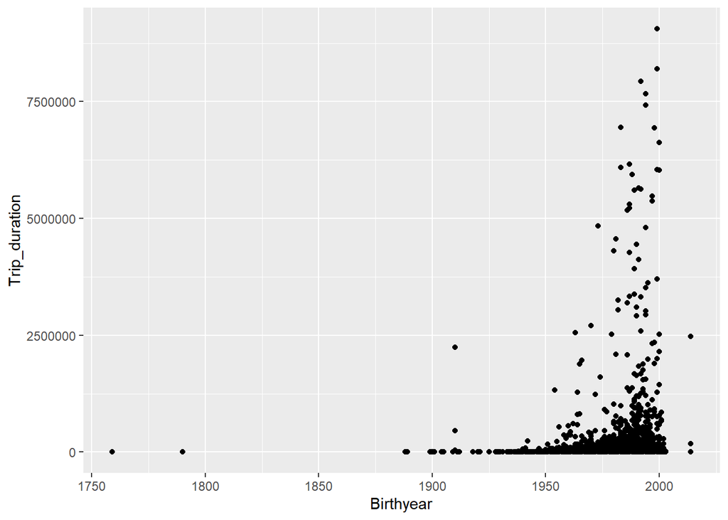

```r
ggplot(data = new_year) +
  geom_point(mapping =aes(x = Birthyear, y = Trip_duration))
```

#### This graph tries to show the relationship between birth year and trip_duration

There is no real relationship between birth year and trip_duration.

### Users by day of the week

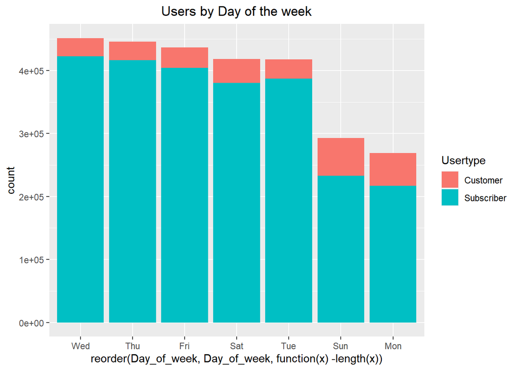

```r
ggplot(new_year,aes(x=reorder(Day_of_week,Day_of_week,function(x)-length(x)),fill=Usertype)) +
   theme(plot.title = element_text(hjust = 0.5))+
   ggtitle("Users by Day of the week") +
  geom_bar()
```

##### This graph shows the order of days in which bikes are most used.

It shows that bikes are used most on Wednesdays and Thursdays and used the least on Mondays and Sundays.

### Customers by day of the week

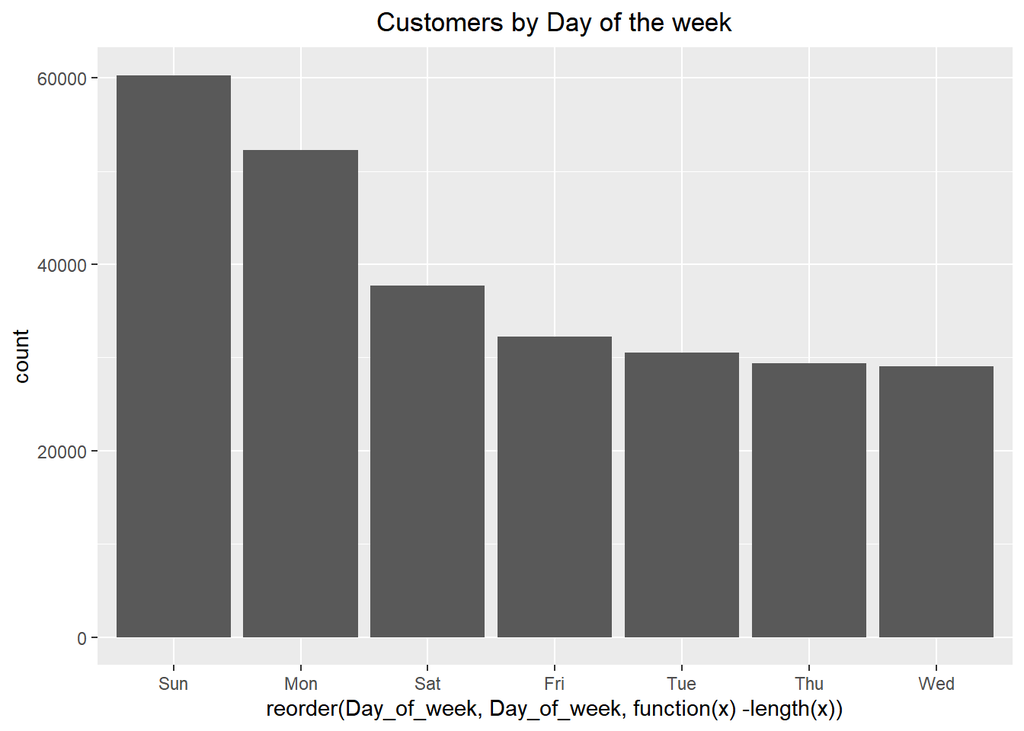

```r
ggplot(customers,aes(x=reorder(Day_of_week,Day_of_week,function(x)-length(x)))) +
   theme(plot.title = element_text(hjust = 0.5))+
   ggtitle("Customers by Day of the week") +
  geom_bar()
```

### Subcribers by day of the week

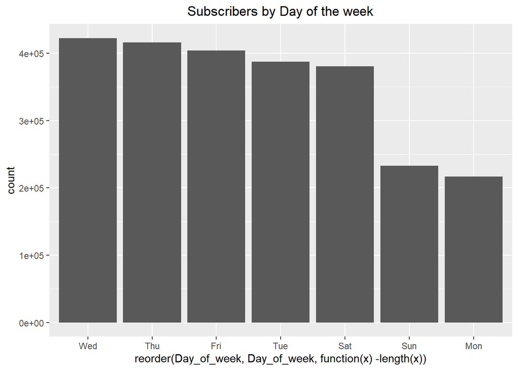

```r
ggplot(subscribers,aes(x=reorder(Day_of_week,Day_of_week,function(x)-length(x)))) +
   theme(plot.title = element_text(hjust = 0.5))+
   ggtitle("Subscribers by Day of the week") +
  geom_bar()
```

### Average Trips

```r
new_year_summary <-
  new_year %>%
  group_by(Day_of_week) %>%
  summarise(average_trip_time=mean(Trip_duration),
            min_trip_time=min(Trip_duration),
            max_trip_time=max(Trip_duration))
new_year_summary[order(new_year_summary$average_trip_time,decreasing = TRUE),]
```

```
## # A tibble: 7 × 4
##   Day_of_week average_trip_time min_trip_time max_trip_time
##   <chr>                   <dbl>         <int>         <int>
## 1 Mon                     1327.            61       6629854
## 2 Sun                     1302.            61       4809091
## 3 Sat                     1100.            61       7939448
## 4 Tue                     1025.            61       8203637
## 5 Wed                      991.            61       9056633
## 6 Fri                      982.            61       7667469
## 7 Thu                      958.            61       5937966
```

##### This is a table showing the overall average, minimum and maximum time spent on the bikes by all users per day .

It shows that users spend the most time on their bikes on Mondays and Sundays and spend the least time on the bikes on Thursdays and Fridays.

### Customers Trips

```r
customer_trips <-
  customers %>%
  group_by(Day_of_week) %>%
  summarise(average_trip_time=mean(Trip_duration),
            min_trip_time=min(Trip_duration),
            max_trip_time=max(Trip_duration))
customer_trips[order(customer_trips$average_trip_time,decreasing = TRUE),]
```

```
## # A tibble: 7 × 4
##   Day_of_week average_trip_time min_trip_time max_trip_time
##   <chr>                   <dbl>         <int>         <int>
## 1 Sat                     3828.            61       7939448
## 2 Tue                     3290.            61       5607711
## 3 Wed                     3143.            61       7420632
## 4 Thu                     3013.            61       5937966
## 5 Mon                     3007.            61       6629854
## 6 Fri                     2885.            62       7667469
## 7 Sun                     2570.            61       1446792
```

##### This table shows the average ,maximum and minimum time used by *customers* on the bikes per day.

It shows that customers spend much time on the bikes during Saturdays and Tuesdays and spend the least time on the bikes on Sundays and Fridays.

### Subscribers Trips

```r
subscriber_trips <-
  subscribers %>%
  group_by(Day_of_week) %>%
  summarise(average_trip_time=mean(Trip_duration),
            min_trip_time=min(Trip_duration),
            max_trip_time=max(Trip_duration))
subscriber_trips[order(subscriber_trips$average_trip_time,decreasing = TRUE),]
```

```
## # A tibble: 7 × 4
##   Day_of_week average_trip_time min_trip_time max_trip_time
##   <chr>                   <dbl>         <int>         <int>
## 1 Sun                      973.            61       4809091
## 2 Mon                      922.            61       2592880
## 3 Tue                      847.            61       8203637
## 4 Wed                      843.            61       9056633
## 5 Fri                      830.            61       6028601
## 6 Sat                      830.            61       4840300
## 7 Thu                      813.            61       5628778
```

##### This table shows the average ,maximum and minimum time used by *subscribers* on the bikes per day.

It shows that subscribers spend much time on the bikes during Sundays and Mondays and spend the least time on the bikes on Saturdays and Thursdays.

```r
#Defining function to get the mode
getmode<-function(v) {
  uniqv <- unique(v)
  uniqv[which.max(tabulate(match(v, uniqv)))]
}
```

### Popular places

```r
common_places <-
  new_year %>%
  summarise(common_Start_station = getmode(new_year$Start_station_name),
            common_End_station = getmode(new_year$End_station_name),
            customers_Start_station = getmode(new_year[new_year$Usertype=="Customer",
                                                      "Start_station_name"]),
            customers_End_station = getmode(new_year[new_year$Usertype=="Customer",
                                                    "End_station_name"]),
            subscribers_Start_station=getmode(new_year[new_year$Usertype=="Subscriber",
                                              "Start_station_name"]),
            subscribers_End_station = getmode(new_year[new_year$Usertype=="Subscriber",
                                                      "End_station_name"]))

common_places
```

```
##   common_Start_station           common_End_station customers_Start_station
## 1  Canal St & Adams St Clinton St & Washington Blvd Streeter Dr & Grand Ave
##     customers_End_station subscribers_Start_station
## 1 Streeter Dr & Grand Ave       Canal St & Adams St
##        subscribers_End_station
## 1 Clinton St & Washington Blvd
```

##### This table show the most common start and end station name for all users,Customers and subscribers.

It shows that the common start station and end station for customers are the same.

### Usertype by Gender

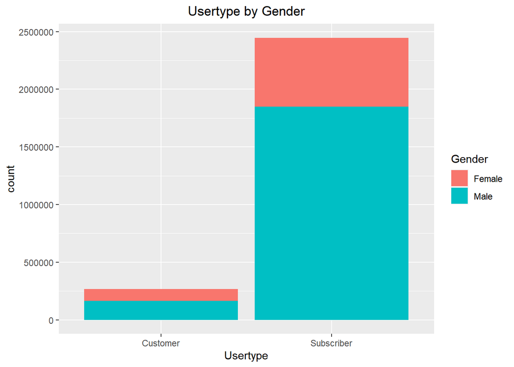

```r
new_year<- new_year[!(new_year$Gender==""),]
ggplot(data = new_year) +
theme(plot.title = element_text(hjust = 0.5))+
ggtitle("Usertype by Gender") +
geom_bar(mapping =aes(x = Usertype, fill =Gender ))
```

##### This graph shows the distribution of each gender for each usertype.

It shows that males are many for each Usertypes compared to females.

### Composition of Subscribers

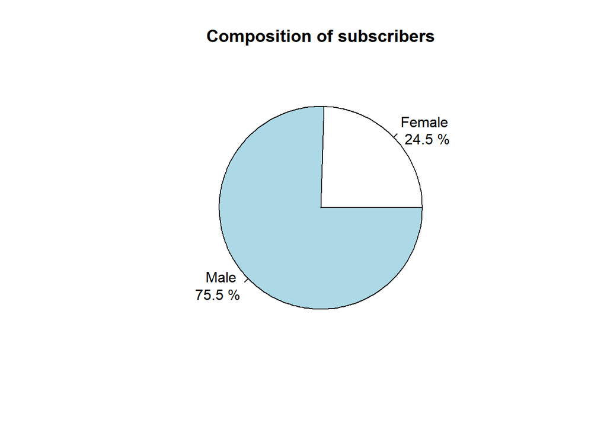

```r
subscribers<- subscribers[!(subscribers$Gender==""),]
sub<-table(subscribers$Gender)
sub_lab<-c("Female","Male")
percent <- round(100*sub/sum(sub),1)
pie(sub,
          labels=paste(sub_lab, "\n" ,percent, "%",sep = " "),
          labelcol = "black",
          labelcex = 1.1,
          theta = 1.2, main="Composition of subscribers")
```

##### This Pie chart shows the percentage male and female that are subscribers.

### Composition of customers

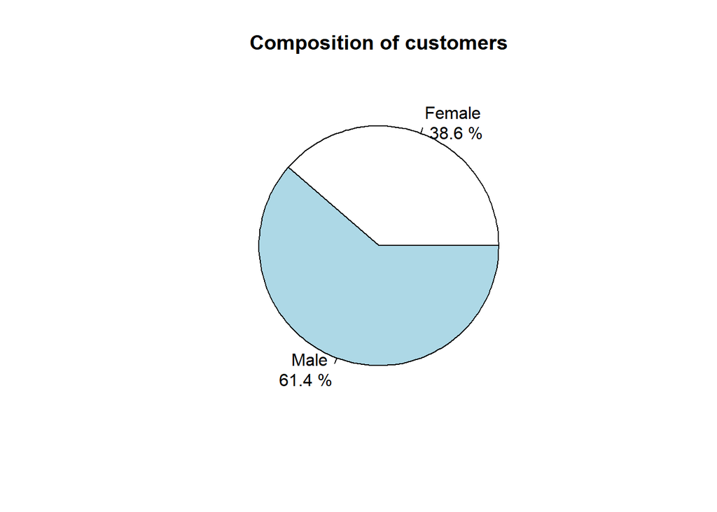

```r
customers<- customers[!(customers$Gender==""),]
cust<-table(customers$Gender)
cust_lab<-c("Female","Male")
percent <- round(100*cust/sum(cust),1)
pie(cust,
          labels=paste(cust_lab, "\n" ,percent, "%",sep = " "),
          labelcol = "black",
          labelcex = 1.1,
          theta = 1.2, main="Composition of customers")
```

##### This Pie chart shows the percentage male and female that are customers.

### Usertype by Gender

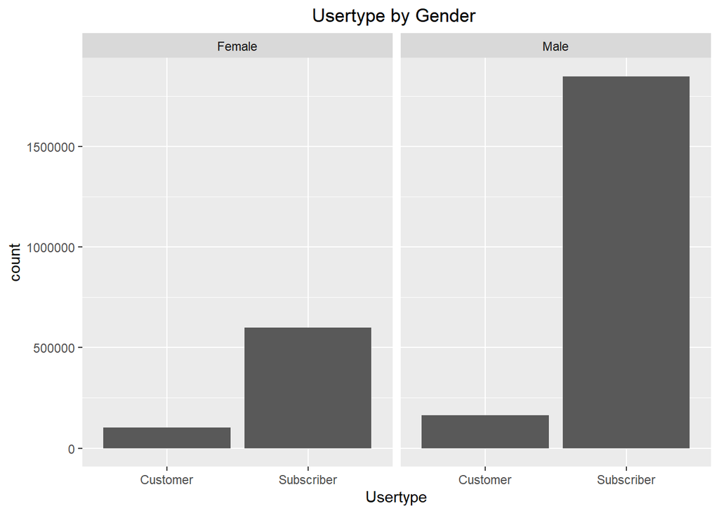

```r
ggplot(data = new_year) +
geom_bar(mapping = aes(x = Usertype)) +
facet_wrap(~Gender) +
theme(plot.title = element_text(hjust = 0.5))+
ggtitle("Usertype by Gender ")
```

##### This is graph shows usertype based on gender.It shows the number of the number of female that are subscribers and customers and also the number of males that are customers and male subscribers.

From this graph it shows that the male and female subscribers are much more than male and female customers.

### Composition of users

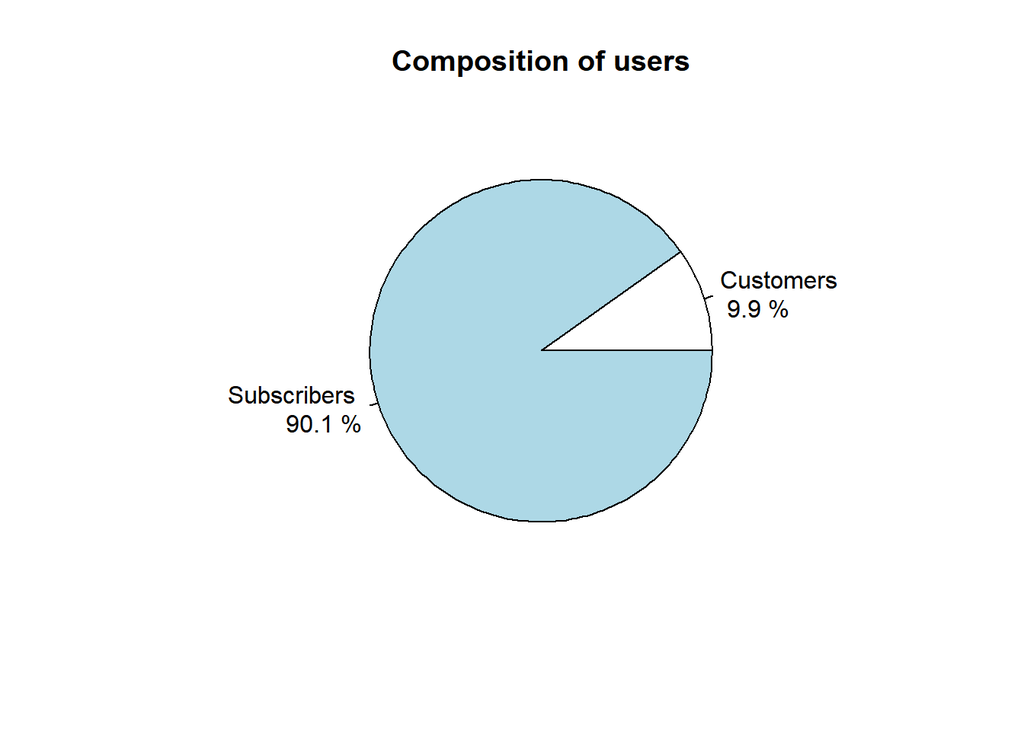

```r
df<-table(new_year$Usertype)
df2<-c("Customers","Subscribers")
percent <- round(100*df/sum(df),1)
pie(df,
          labels=paste(df2, "\n" ,percent, "%",sep = " "),
          labelcol = "black",
          labelcex = 1.1,
          theta = 1.2, main="Composition of users")
```

## Recommendations

### 1) Cyclistic managers can try to make more advertisement that will be targeted towards people that cover shorter distances since most of their subscribers seem to be short distance users.

### 2) Cyclistic managers can try to make more findings as to why subscribers ride bike mostly on Wednesdays and why customers seem to ride the bikes mostly on Sundays as the data does not have information data can be used to answer these questions.

### 3) Cyclistic managers should make more research on this (*Canal St & Adams St*) start station and (*Clinton St & Washington Blvd*) end station to find out why subscribers seem to use this places the most.